# Analysis of Neuro Cog data

Michael Friendly, Matthew Sigal

08 Jun 2016

This script reproduces all of the analysis and graphs for the MANOVA of the `NeuroCog` data in the paper and also includes other analyses not described there. It is set up as an R script that can be “compiled” to HTML, Word, or PDF using `knitr::knit()`. This is most convenient within R Studio via the `File -> Compile Notebook` option.

## Load packages and the data

```r
library(heplots)
library(candisc)
data(NeuroCog, package="heplots")
```

## Fit the MANOVA model, test hypotheses

```r
NC.mlm <- lm(cbind( Speed, Attention, Memory, Verbal, Visual, ProbSolv) ~ Dx,
               data=NeuroCog)
Anova(NC.mlm)
```

```
##
## Type II MANOVA Tests: Pillai test statistic
##    Df test stat approx F num Df den Df  Pr(>F)
## Dx  2     0.299     6.89     12    470 1.6e-11 ***
## ---
## Signif. codes:  0 '***' 0.001 '**' 0.01 '*' 0.05 '.' 0.1 ' ' 1
```

Test contrasts: Control vs. others (`Dx1`), and Schizo- vs. schizoaffective (`Dx2`). These were set up in the original data frame.

```r
contrasts(NeuroCog$Dx)
```

```
##                 [,1] [,2]
## Schizophrenia   -0.5    1
## Schizoaffective -0.5   -1
## Control          1.0    0
```

```r
print(linearHypothesis(NC.mlm, "Dx1"), SSP=FALSE)
```

```
##
## Multivariate Tests:
##                  Df test stat approx F num Df den Df   Pr(>F)
## Pillai            1    0.2891    15.86      6    234 2.81e-15 ***
## Wilks             1    0.7109    15.86      6    234 2.81e-15 ***
## Hotelling-Lawley  1    0.4066    15.86      6    234 2.81e-15 ***
## Roy               1    0.4066    15.86      6    234 2.81e-15 ***
## ---
## Signif. codes:  0 '***' 0.001 '**' 0.01 '*' 0.05 '.' 0.1 ' ' 1
```

```r
print(linearHypothesis(NC.mlm, "Dx2"), SSP=FALSE)
```

```
##
## Multivariate Tests:
##                  Df test stat approx F num Df den Df Pr(>F)
## Pillai            1    0.0064   0.2493      6    234  0.959
## Wilks             1    0.9936   0.2493      6    234  0.959
## Hotelling-Lawley  1    0.0064   0.2493      6    234  0.959
## Roy               1    0.0064   0.2493      6    234  0.959
```

## Examine residuals in a chi-square QQ plot

The standard plot shows no problems. Using robust estimates to calculate Mahalanobis $D^2$ shows a few potential outliers, but we ignore these.

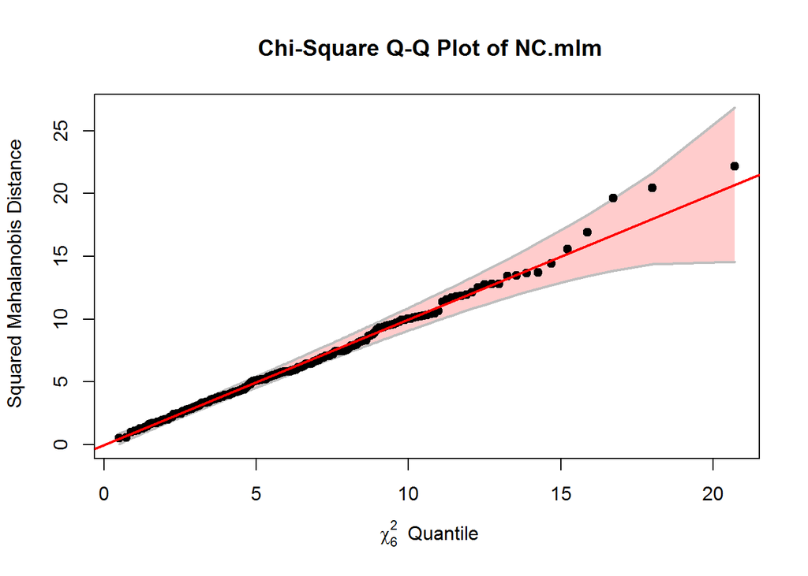

```r
cqplot(NC.mlm)
```

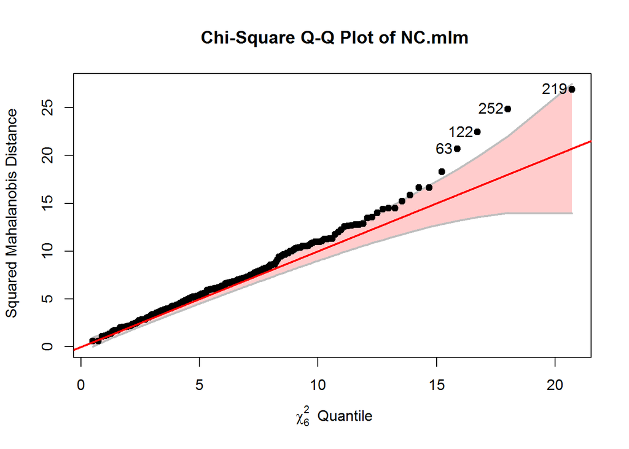

```r
cqplot(NC.mlm, method="mve", id.n=4)
```

## HE plot

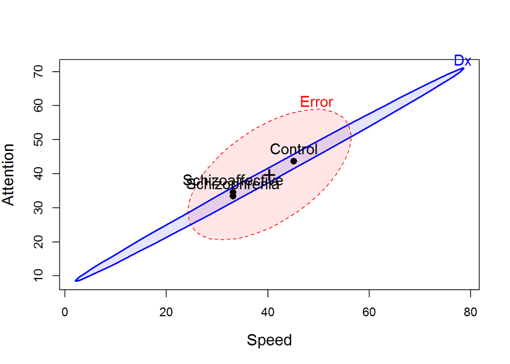

```r
heplot(NC.mlm, fill=TRUE, fill.alpha=0.1,
    cex.lab=1.3, cex=1.25)
```

## pairwise HE plots

All pairs of variables show the same pattern of group differences on the responses

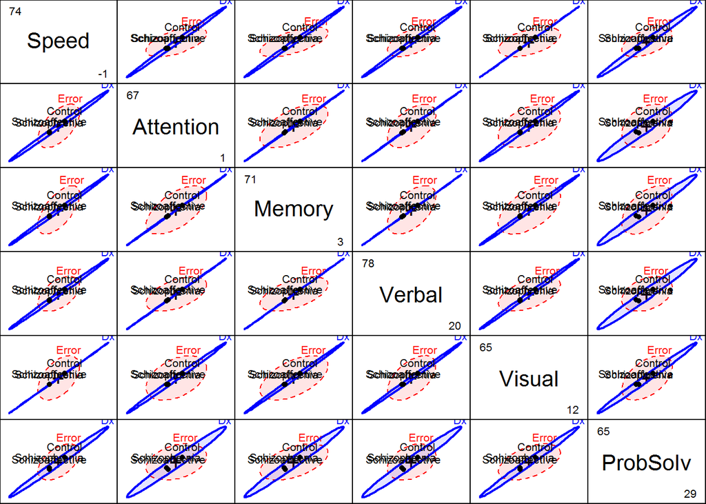

```r
pairs(NC.mlm, var.cex=2, fill=TRUE, fill.alpha=0.1)
```

## canonical discriminant analysis

The canonical analysis shows a simple, 1-dimensional structure to group differences on the response variables. Plotting the canonical variates provides a very simple interpretation.

```r
NC.can <- candisc(NC.mlm)
NC.can
```

[output not shown]

tweak `var.pos` of labels in this plot to avoid overlap

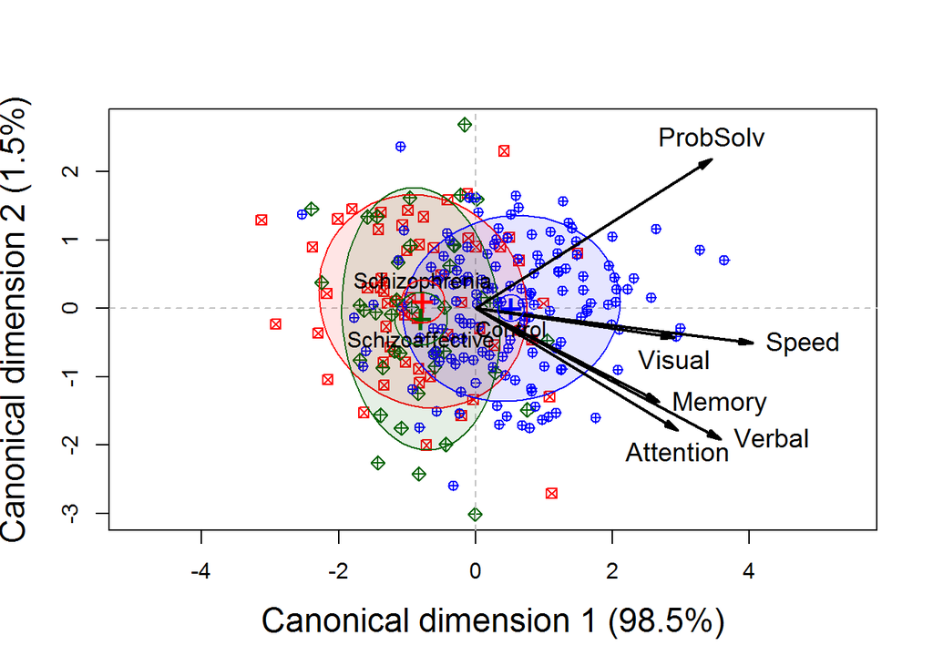

```r
pos <- c(4, 1, 4, 4, 1, 3)
col <- c("red", "darkgreen", "blue")
plot(NC.can, ellipse=TRUE, rev.axes=c(TRUE,FALSE), pch=c(7,9,10),
    var.cex=1.2, cex.lab=1.5, var.lwd=2,  scale=4.5, col=col,
    var.col="black", var.pos=pos,
    prefix="Canonical dimension ")
```

## equivalent plot, as an HE plot

The variable vectors show the relationships (correlations) of the response variables to the canonical dimensions.

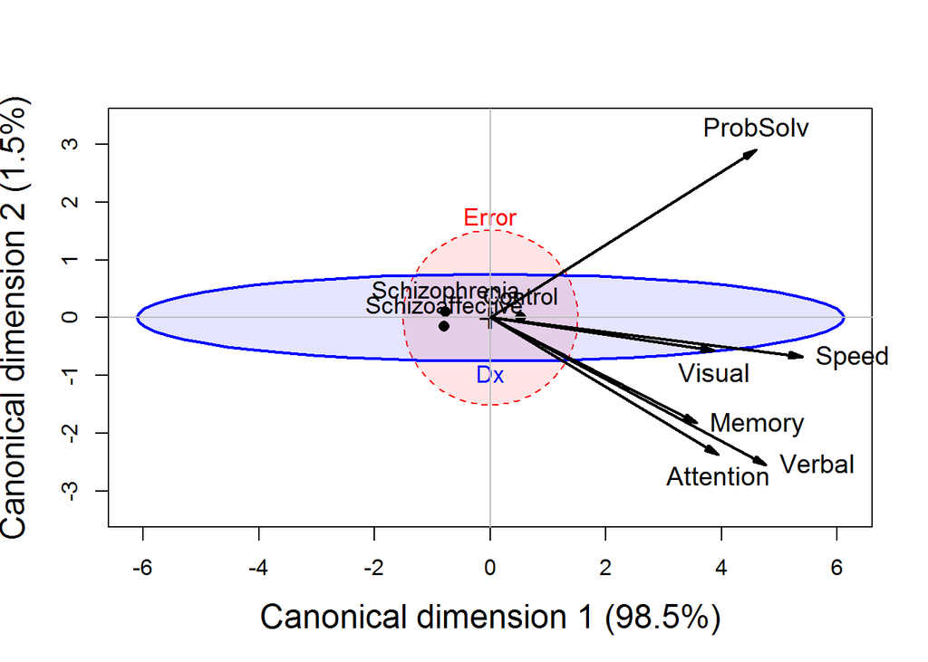

```r
heplot(NC.can,
    fill=TRUE, fill.alpha=.1,  scale=6,
    cex.lab=1.5, var.cex=1.2,
    var.lwd=2, var.col="black",  var.pos=pos,
    label.pos=c(3,1), cex=1.1, rev.axes=c(TRUE,FALSE),
    prefix="Canonical dimension ")
```

## fit a robust MLM, downweighting possible outliers

As a sensitivity analysis, we could compare results with those of a robust MLM

```r
NC.rlm <- robmlm(cbind( Speed, Attention, Memory, Verbal, Visual, ProbSolv) ~ Dx,
               data=NeuroCog)
Anova(NC.rlm)
```

```
##
## Type II MANOVA Tests: Pillai test statistic
##    Df test stat approx F num Df den Df  Pr(>F)
## Dx  2     0.329     7.72     12    470 3.8e-13 ***
## ---
## Signif. codes:  0 '***' 0.001 '**' 0.01 '*' 0.05 '.' 0.1 ' ' 1
```

```r
# plot weights
#plot(NC.rlm, id.weight=.5)
```